# Risk Factor Analysis

## Outcome Variable

**Outcome Variable:** swasted

## Predictor Variables

**Intervention Variable:** mwtkg

**Adjustment Set:**

unadjusted

## Stratifying Variables

The analysis was stratified on these variable(s):

- agecat
- studyid
- country

## Data Summary

| agecat | studyid | country | mwtkg | swasted | n_cell | n |
| --- | --- | --- | --- | --- | --- | --- |
| Birth | JiVitA-3 | BANGLADESH | >=58 kg | 0 | 422 | 17995 |
| Birth | JiVitA-3 | BANGLADESH | >=58 kg | 1 | 5 | 17995 |
| Birth | JiVitA-3 | BANGLADESH | <52 kg | 0 | 16029 | 17995 |
| Birth | JiVitA-3 | BANGLADESH | <52 kg | 1 | 322 | 17995 |
| Birth | JiVitA-3 | BANGLADESH | [52-58) kg | 0 | 1195 | 17995 |
| Birth | JiVitA-3 | BANGLADESH | [52-58) kg | 1 | 22 | 17995 |
| Birth | MAL-ED | BANGLADESH | >=58 kg | 0 | 36 | 209 |
| Birth | MAL-ED | BANGLADESH | >=58 kg | 1 | 1 | 209 |
| Birth | MAL-ED | BANGLADESH | <52 kg | 0 | 124 | 209 |
| Birth | MAL-ED | BANGLADESH | <52 kg | 1 | 7 | 209 |
| Birth | MAL-ED | BANGLADESH | [52-58) kg | 0 | 41 | 209 |
| Birth | MAL-ED | BANGLADESH | [52-58) kg | 1 | 0 | 209 |
| Birth | MAL-ED | BRAZIL | >=58 kg | 0 | 33 | 61 |
| Birth | MAL-ED | BRAZIL | >=58 kg | 1 | 0 | 61 |
| Birth | MAL-ED | BRAZIL | <52 kg | 0 | 14 | 61 |
| Birth | MAL-ED | BRAZIL | <52 kg | 1 | 0 | 61 |
| Birth | MAL-ED | BRAZIL | [52-58) kg | 0 | 14 | 61 |
| Birth | MAL-ED | BRAZIL | [52-58) kg | 1 | 0 | 61 |
| Birth | MAL-ED | INDIA | >=58 kg | 0 | 6 | 41 |
| Birth | MAL-ED | INDIA | >=58 kg | 1 | 0 | 41 |
| Birth | MAL-ED | INDIA | <52 kg | 0 | 28 | 41 |
| Birth | MAL-ED | INDIA | <52 kg | 1 | 0 | 41 |
| Birth | MAL-ED | INDIA | [52-58) kg | 0 | 7 | 41 |
| Birth | MAL-ED | INDIA | [52-58) kg | 1 | 0 | 41 |
| Birth | MAL-ED | NEPAL | >=58 kg | 0 | 9 | 26 |
| Birth | MAL-ED | NEPAL | >=58 kg | 1 | 0 | 26 |
| Birth | MAL-ED | NEPAL | <52 kg | 0 | 7 | 26 |
| Birth | MAL-ED | NEPAL | <52 kg | 1 | 0 | 26 |
| Birth | MAL-ED | NEPAL | [52-58) kg | 0 | 9 | 26 |
| Birth | MAL-ED | NEPAL | [52-58) kg | 1 | 1 | 26 |

[output cut: 240 more lines]

The following strata were considered:

- agecat: 24 months, studyid: JiVitA-3, country: BANGLADESH
- agecat: 24 months, studyid: LCNI-5, country: MALAWI
- agecat: 24 months, studyid: MAL-ED, country: BANGLADESH
- agecat: 24 months, studyid: MAL-ED, country: BRAZIL
- agecat: 24 months, studyid: MAL-ED, country: INDIA
- agecat: 24 months, studyid: MAL-ED, country: NEPAL
- agecat: 24 months, studyid: MAL-ED, country: PERU
- agecat: 24 months, studyid: MAL-ED, country: SOUTH AFRICA
- agecat: 24 months, studyid: MAL-ED, country: TANZANIA, UNITED REPUBLIC OF
- agecat: 24 months, studyid: NIH-Birth, country: BANGLADESH
- agecat: 24 months, studyid: NIH-Crypto, country: BANGLADESH
- agecat: 24 months, studyid: PROBIT, country: BELARUS
- agecat: 24 months, studyid: PROVIDE, country: BANGLADESH
- agecat: 24 months, studyid: TanzaniaChild2, country: TANZANIA, UNITED REPUBLIC OF
- agecat: 24 months, studyid: ZVITAMBO, country: ZIMBABWE
- agecat: 6 months, studyid: JiVitA-3, country: BANGLADESH
- agecat: 6 months, studyid: LCNI-5, country: MALAWI
- agecat: 6 months, studyid: MAL-ED, country: BANGLADESH
- agecat: 6 months, studyid: MAL-ED, country: BRAZIL
- agecat: 6 months, studyid: MAL-ED, country: INDIA
- agecat: 6 months, studyid: MAL-ED, country: NEPAL
- agecat: 6 months, studyid: MAL-ED, country: PERU
- agecat: 6 months, studyid: MAL-ED, country: SOUTH AFRICA
- agecat: 6 months, studyid: MAL-ED, country: TANZANIA, UNITED REPUBLIC OF
- agecat: 6 months, studyid: NIH-Birth, country: BANGLADESH
- agecat: 6 months, studyid: NIH-Crypto, country: BANGLADESH
- agecat: 6 months, studyid: PROBIT, country: BELARUS
- agecat: 6 months, studyid: PROVIDE, country: BANGLADESH
- agecat: 6 months, studyid: SAS-CompFeed, country: INDIA
- agecat: 6 months, studyid: TanzaniaChild2, country: TANZANIA, UNITED REPUBLIC OF
- agecat: 6 months, studyid: ZVITAMBO, country: ZIMBABWE
- agecat: Birth, studyid: JiVitA-3, country: BANGLADESH
- agecat: Birth, studyid: MAL-ED, country: BANGLADESH
- agecat: Birth, studyid: MAL-ED, country: BRAZIL
- agecat: Birth, studyid: MAL-ED, country: INDIA
- agecat: Birth, studyid: MAL-ED, country: NEPAL
- agecat: Birth, studyid: MAL-ED, country: PERU
- agecat: Birth, studyid: MAL-ED, country: SOUTH AFRICA
- agecat: Birth, studyid: MAL-ED, country: TANZANIA, UNITED REPUBLIC OF
- agecat: Birth, studyid: NIH-Birth, country: BANGLADESH
- agecat: Birth, studyid: NIH-Crypto, country: BANGLADESH
- agecat: Birth, studyid: PROBIT, country: BELARUS
- agecat: Birth, studyid: PROVIDE, country: BANGLADESH
- agecat: Birth, studyid: SAS-CompFeed, country: INDIA
- agecat: Birth, studyid: ZVITAMBO, country: ZIMBABWE

### Dropped Strata

Some strata were dropped due to rare outcomes:

- agecat: Birth, studyid: MAL-ED, country: BANGLADESH
- agecat: Birth, studyid: MAL-ED, country: BRAZIL
- agecat: Birth, studyid: MAL-ED, country: INDIA
- agecat: Birth, studyid: MAL-ED, country: NEPAL
- agecat: Birth, studyid: MAL-ED, country: PERU
- agecat: Birth, studyid: MAL-ED, country: SOUTH AFRICA
- agecat: Birth, studyid: MAL-ED, country: TANZANIA, UNITED REPUBLIC OF
- agecat: Birth, studyid: NIH-Birth, country: BANGLADESH
- agecat: Birth, studyid: PROVIDE, country: BANGLADESH
- agecat: Birth, studyid: SAS-CompFeed, country: INDIA
- agecat: 6 months, studyid: JiVitA-3, country: BANGLADESH
- agecat: 6 months, studyid: LCNI-5, country: MALAWI
- agecat: 6 months, studyid: MAL-ED, country: BANGLADESH
- agecat: 6 months, studyid: MAL-ED, country: BRAZIL
- agecat: 6 months, studyid: MAL-ED, country: INDIA
- agecat: 6 months, studyid: MAL-ED, country: NEPAL
- agecat: 6 months, studyid: MAL-ED, country: PERU
- agecat: 6 months, studyid: MAL-ED, country: SOUTH AFRICA
- agecat: 6 months, studyid: MAL-ED, country: TANZANIA, UNITED REPUBLIC OF
- agecat: 6 months, studyid: NIH-Birth, country: BANGLADESH
- agecat: 6 months, studyid: NIH-Crypto, country: BANGLADESH
- agecat: 6 months, studyid: PROBIT, country: BELARUS
- agecat: 6 months, studyid: PROVIDE, country: BANGLADESH
- agecat: 6 months, studyid: SAS-CompFeed, country: INDIA
- agecat: 6 months, studyid: TanzaniaChild2, country: TANZANIA, UNITED REPUBLIC OF
- agecat: 24 months, studyid: LCNI-5, country: MALAWI
- agecat: 24 months, studyid: MAL-ED, country: BANGLADESH
- agecat: 24 months, studyid: MAL-ED, country: BRAZIL
- agecat: 24 months, studyid: MAL-ED, country: INDIA
- agecat: 24 months, studyid: MAL-ED, country: NEPAL
- agecat: 24 months, studyid: MAL-ED, country: PERU
- agecat: 24 months, studyid: MAL-ED, country: SOUTH AFRICA
- agecat: 24 months, studyid: MAL-ED, country: TANZANIA, UNITED REPUBLIC OF
- agecat: 24 months, studyid: NIH-Birth, country: BANGLADESH
- agecat: 24 months, studyid: NIH-Crypto, country: BANGLADESH
- agecat: 24 months, studyid: PROBIT, country: BELARUS
- agecat: 24 months, studyid: PROVIDE, country: BANGLADESH
- agecat: 24 months, studyid: TanzaniaChild2, country: TANZANIA, UNITED REPUBLIC OF
- agecat: 24 months, studyid: ZVITAMBO, country: ZIMBABWE

## Methods Detail

We’re interested in the causal parameters $E[Y_a]$ for all values of $a \in \mathcal{A}$. These parameters represent the mean outcome if, possibly contrary to fact, we intervened to set all units to have $A=a$. Under the randomization and positivity assumptions, these are identified by the statistical parameters $\psi_a=E_W[E_{Y|A,W}(Y|A=a,W)]$. In addition, we’re interested in the mean of $Y$, $E[Y]$ under no intervention (the observed mean). We will estimate these parameters by using SuperLearner to fit the relevant likelihood factors – $E_{Y|A,W}(Y|A=a,W)$ and $p(A=a|W)$, and then updating our likelihood fit using a joint TMLE.

For unadjusted analyses ($W=\{\}$), initial likelihoods were estimated using Lrnr_glm to estimate the simple $E(Y|A)$ and Lrnr_mean to estimate $p(A)$. For adjusted analyses, a small library containing Lrnr_glmnet, Lrnr_xgboost, and Lrnr_mean was used.

Having estimated these parameters, we will then use the delta method to estimate relative risks and attributable risks relative to a prespecified baseline level of $A$.

# Results Detail

## Results Plots

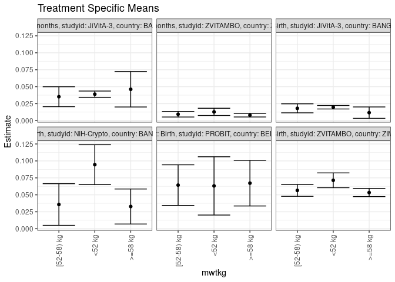

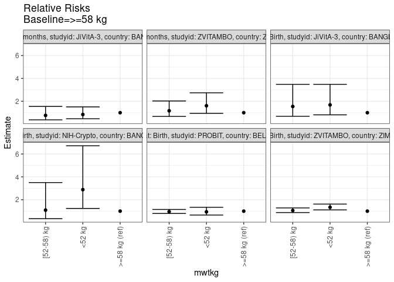

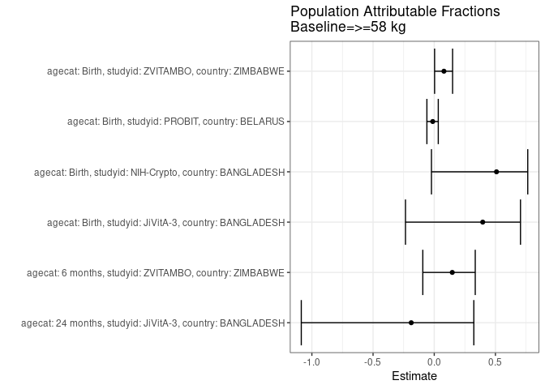

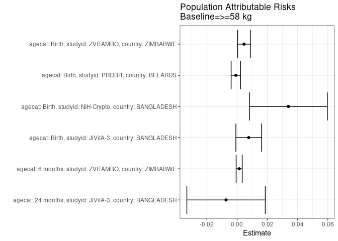

## Results Table

### Parameter: TSM

| agecat | studyid | country | intervention_level | baseline_level | estimate | ci_lower | ci_upper |
| --- | --- | --- | --- | --- | --- | --- | --- |
| Birth | JiVitA-3 | BANGLADESH | >=58 kg | NA | 0.0117096 | 0.0033075 | 0.0201117 |
| Birth | JiVitA-3 | BANGLADESH | <52 kg | NA | 0.0196930 | 0.0171157 | 0.0222703 |
| Birth | JiVitA-3 | BANGLADESH | [52-58) kg | NA | 0.0180772 | 0.0114191 | 0.0247354 |
| Birth | NIH-Crypto | BANGLADESH | >=58 kg | NA | 0.0327869 | 0.0069677 | 0.0586061 |
| Birth | NIH-Crypto | BANGLADESH | <52 kg | NA | 0.0944882 | 0.0650961 | 0.1238803 |
| Birth | NIH-Crypto | BANGLADESH | [52-58) kg | NA | 0.0357143 | 0.0049521 | 0.0664764 |
| Birth | PROBIT | BELARUS | >=58 kg | NA | 0.0672080 | 0.0335450 | 0.1008710 |
| Birth | PROBIT | BELARUS | <52 kg | NA | 0.0631673 | 0.0201937 | 0.1061408 |
| Birth | PROBIT | BELARUS | [52-58) kg | NA | 0.0643101 | 0.0343350 | 0.0942851 |
| Birth | ZVITAMBO | ZIMBABWE | >=58 kg | NA | 0.0533456 | 0.0473818 | 0.0593093 |
| Birth | ZVITAMBO | ZIMBABWE | <52 kg | NA | 0.0714286 | 0.0605216 | 0.0823355 |
| Birth | ZVITAMBO | ZIMBABWE | [52-58) kg | NA | 0.0565266 | 0.0477976 | 0.0652556 |
| 6 months | ZVITAMBO | ZIMBABWE | >=58 kg | NA | 0.0079906 | 0.0053153 | 0.0106659 |
| 6 months | ZVITAMBO | ZIMBABWE | <52 kg | NA | 0.0128430 | 0.0075106 | 0.0181754 |
| 6 months | ZVITAMBO | ZIMBABWE | [52-58) kg | NA | 0.0093371 | 0.0052639 | 0.0134102 |
| 24 months | JiVitA-3 | BANGLADESH | >=58 kg | NA | 0.0461538 | 0.0200673 | 0.0722404 |
| 24 months | JiVitA-3 | BANGLADESH | <52 kg | NA | 0.0389279 | 0.0342901 | 0.0435657 |
| 24 months | JiVitA-3 | BANGLADESH | [52-58) kg | NA | 0.0352113 | 0.0205132 | 0.0499094 |

### Parameter: E(Y)

| agecat | studyid | country | intervention_level | baseline_level | estimate | ci_lower | ci_upper |
| --- | --- | --- | --- | --- | --- | --- | --- |
| Birth | JiVitA-3 | BANGLADESH | NA | NA | 0.0193943 | 0.0169827 | 0.0218059 |
| Birth | NIH-Crypto | BANGLADESH | NA | NA | 0.0667614 | 0.0483100 | 0.0852128 |
| Birth | PROBIT | BELARUS | NA | NA | 0.0663794 | 0.0332724 | 0.0994865 |
| Birth | ZVITAMBO | ZIMBABWE | NA | NA | 0.0579428 | 0.0534276 | 0.0624581 |
| 6 months | ZVITAMBO | ZIMBABWE | NA | NA | 0.0093711 | 0.0072741 | 0.0114682 |
| 24 months | JiVitA-3 | BANGLADESH | NA | NA | 0.0388462 | 0.0345183 | 0.0431742 |

### Parameter: RR

| agecat | studyid | country | intervention_level | baseline_level | estimate | ci_lower | ci_upper |
| --- | --- | --- | --- | --- | --- | --- | --- |
| Birth | JiVitA-3 | BANGLADESH | >=58 kg | >=58 kg | 1.0000000 | 1.0000000 | 1.000000 |
| Birth | JiVitA-3 | BANGLADESH | <52 kg | >=58 kg | 1.6817809 | 0.8127983 | 3.479814 |
| Birth | JiVitA-3 | BANGLADESH | [52-58) kg | >=58 kg | 1.5437962 | 0.6849233 | 3.479670 |
| Birth | NIH-Crypto | BANGLADESH | >=58 kg | >=58 kg | 1.0000000 | 1.0000000 | 1.000000 |
| Birth | NIH-Crypto | BANGLADESH | <52 kg | >=58 kg | 2.8818898 | 1.2358389 | 6.720365 |
| Birth | NIH-Crypto | BANGLADESH | [52-58) kg | >=58 kg | 1.0892857 | 0.3390722 | 3.499382 |
| Birth | PROBIT | BELARUS | >=58 kg | >=58 kg | 1.0000000 | 1.0000000 | 1.000000 |
| Birth | PROBIT | BELARUS | <52 kg | >=58 kg | 0.9398773 | 0.6601036 | 1.338228 |
| Birth | PROBIT | BELARUS | [52-58) kg | >=58 kg | 0.9568811 | 0.7975042 | 1.148109 |
| Birth | ZVITAMBO | ZIMBABWE | >=58 kg | >=58 kg | 1.0000000 | 1.0000000 | 1.000000 |
| Birth | ZVITAMBO | ZIMBABWE | <52 kg | >=58 kg | 1.3389789 | 1.1081152 | 1.617941 |
| Birth | ZVITAMBO | ZIMBABWE | [52-58) kg | >=58 kg | 1.0596307 | 0.8757089 | 1.282181 |
| 6 months | ZVITAMBO | ZIMBABWE | >=58 kg | >=58 kg | 1.0000000 | 1.0000000 | 1.000000 |
| 6 months | ZVITAMBO | ZIMBABWE | <52 kg | >=58 kg | 1.6072594 | 0.9428563 | 2.739848 |
| 6 months | ZVITAMBO | ZIMBABWE | [52-58) kg | >=58 kg | 1.1685066 | 0.6742321 | 2.025130 |
| 24 months | JiVitA-3 | BANGLADESH | >=58 kg | >=58 kg | 1.0000000 | 1.0000000 | 1.000000 |
| 24 months | JiVitA-3 | BANGLADESH | <52 kg | >=58 kg | 0.8434376 | 0.4717300 | 1.508038 |
| 24 months | JiVitA-3 | BANGLADESH | [52-58) kg | >=58 kg | 0.7629108 | 0.3756188 | 1.549531 |

### Parameter: PAR

| agecat | studyid | country | intervention_level | baseline_level | estimate | ci_lower | ci_upper |
| --- | --- | --- | --- | --- | --- | --- | --- |
| Birth | JiVitA-3 | BANGLADESH | >=58 kg | NA | 0.0076847 | -0.0008191 | 0.0161884 |
| Birth | NIH-Crypto | BANGLADESH | >=58 kg | NA | 0.0339745 | 0.0082740 | 0.0596749 |
| Birth | PROBIT | BELARUS | >=58 kg | NA | -0.0008285 | -0.0039430 | 0.0022860 |
| Birth | ZVITAMBO | ZIMBABWE | >=58 kg | NA | 0.0045973 | 0.0003276 | 0.0088670 |
| 6 months | ZVITAMBO | ZIMBABWE | >=58 kg | NA | 0.0013805 | -0.0006306 | 0.0033917 |
| 24 months | JiVitA-3 | BANGLADESH | >=58 kg | NA | -0.0073076 | -0.0332464 | 0.0186312 |

### Parameter: PAF

| agecat | studyid | country | intervention_level | baseline_level | estimate | ci_lower | ci_upper |
| --- | --- | --- | --- | --- | --- | --- | --- |
| Birth | JiVitA-3 | BANGLADESH | >=58 kg | NA | 0.3962341 | -0.2351236 | 0.7048609 |
| Birth | NIH-Crypto | BANGLADESH | >=58 kg | NA | 0.5088943 | -0.0227709 | 0.7641849 |
| Birth | PROBIT | BELARUS | >=58 kg | NA | -0.0124820 | -0.0600695 | 0.0329693 |
| Birth | ZVITAMBO | ZIMBABWE | >=58 kg | NA | 0.0793417 | 0.0028743 | 0.1499449 |
| 6 months | ZVITAMBO | ZIMBABWE | >=58 kg | NA | 0.1473189 | -0.0934985 | 0.3351020 |
| 24 months | JiVitA-3 | BANGLADESH | >=58 kg | NA | -0.1881161 | -1.0865684 | 0.3234730 |